# Modeling Average SAT Scores of New York City Public High Schools

Delia Corridon

### Project Introduction

The data frame used in this project was created by combining two separate data frames from the following sources: NYC DOE public high school directory 2014-2015 (https://data.cityofnewyork.us/Education/2014-2015-DOE-High-School-Directory/n3p6-zve2) and average SAT scores for all NYC public high schools for 2014-2015 school year (https://www.kaggle.com/nycopendata/high-schools/version/1). In combining the two frames, the relevant variables were selected and consolidated using `bind_cols()`. The observations that were missing data were removed from the final data frame. This is becuase there was a lack of documentation about what “NA” indicated (that no students at the school took the SAT or that there was no data collected on that school at all). The resulting data frame analyzed in this project contains average SAT scores, the number of students that took the test, demographic information, and the location of 375 New York City public high schools.

This project explored how the demographic makeup of these public high schools correlate with average SAT scores. The SAT is a flawed test of intelligence and academic performance. While it is supposed to be a universal indicator of academic abilities, students with access to tutors and prep courses are at a massive advantage. Because of perpetual, systemic wealth and racial inequalities, students with access to these resources are overwhelmingly white and wealthy. This project explores that concept.

The outcome variable used in the following modeling is `avg_sat_total`. It is important to acknowledge that the Department of Education data only includes four racial categories: white, black, asian, and hispanic. It is important to acknowledge that obviously there are a multitude more of races and ethnicities that the DOE failed to include.

### Exploratory Data Analysis

#### Average Sat Scores per Section and Overall

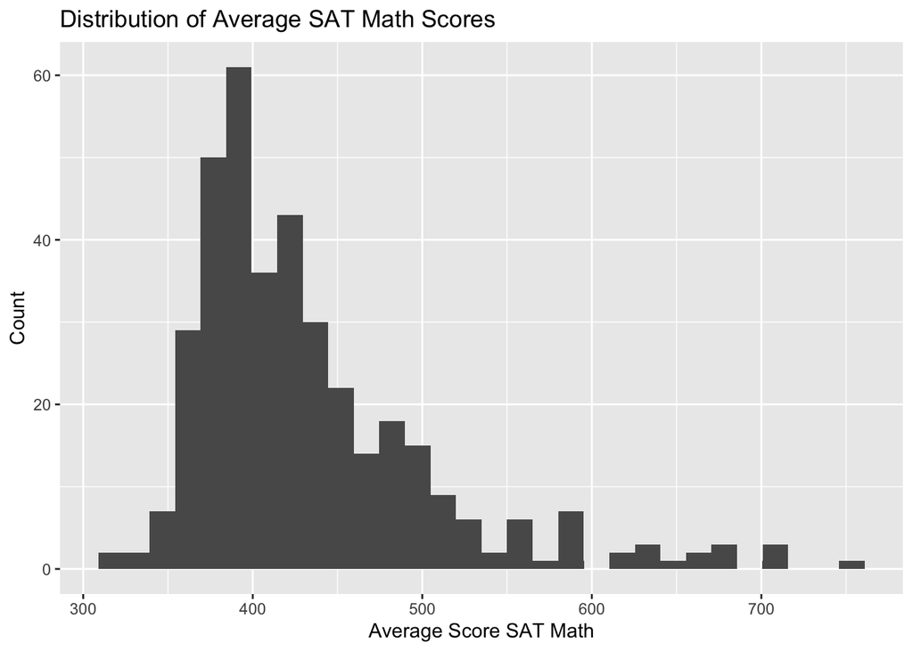

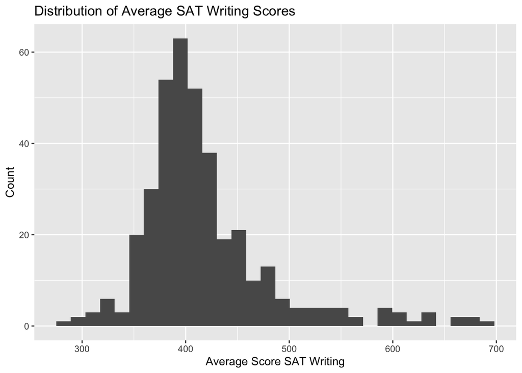

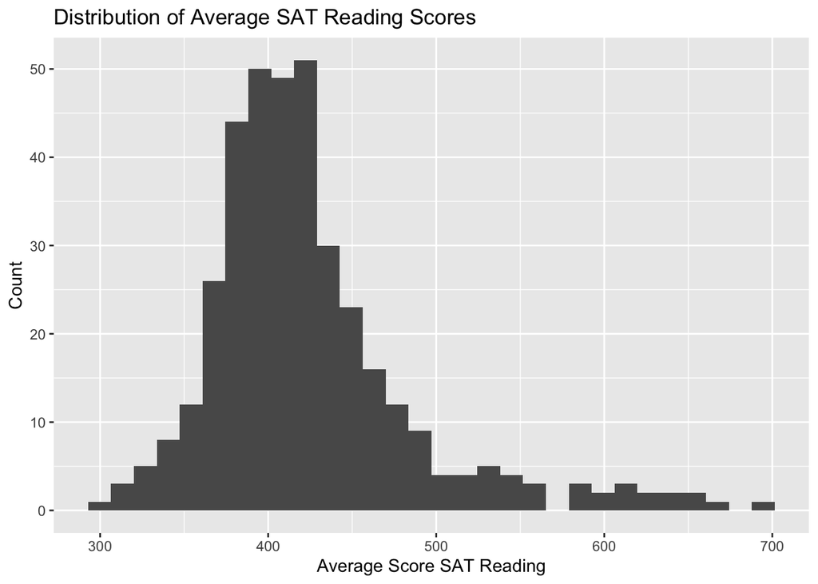

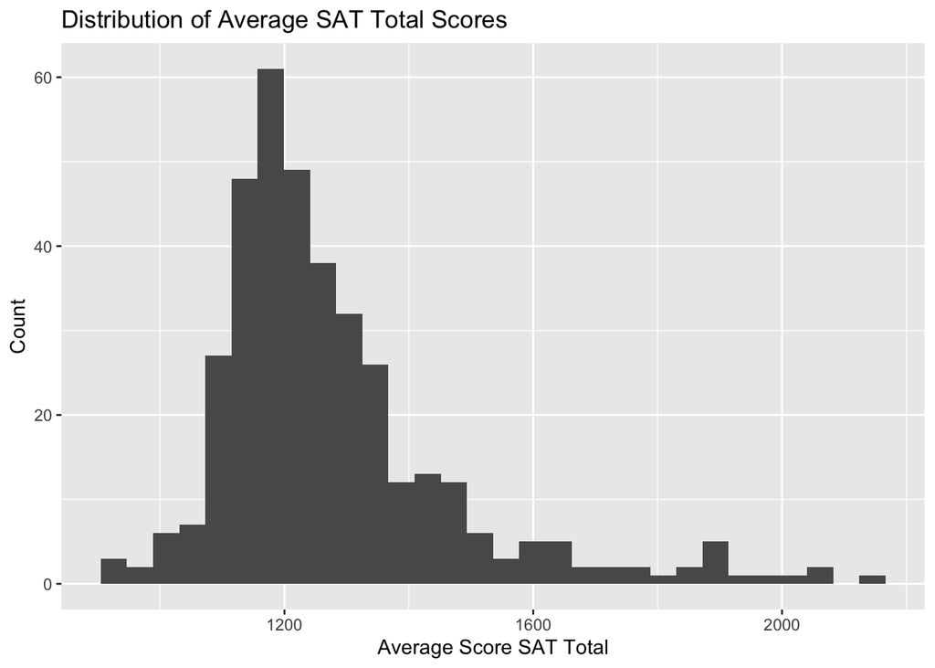

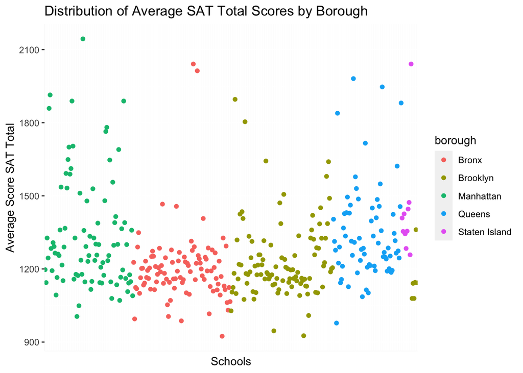

#### Sample of Demographics in 5 Schools

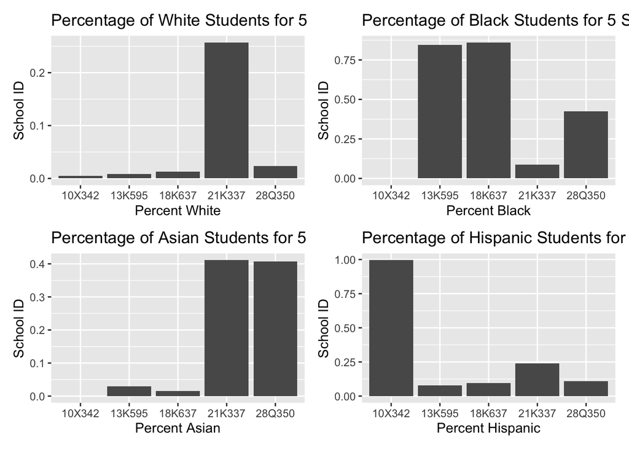

#### Scatterplot of Demographics vs. SAT Scores

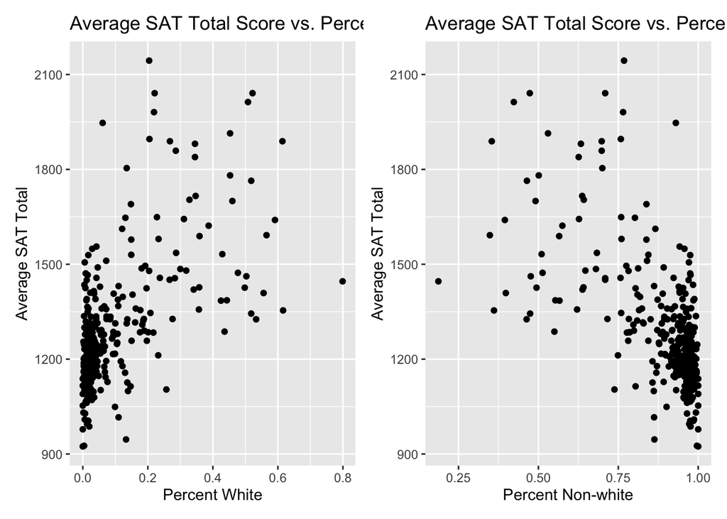

### Modeling

#### Split the Data

Here, the data is split into a training and testing set. The training set will be used to fit and train the models, while the test set will not be used until the model has been fit and the best model has been determined.

#### Set Up Cross Validation

Cross-validation is an important step to improve data accuracy. Cross-validation is a method of resampling, which means the model is being fitted on more separate samples of the dataset. This improves the fit of the model and the accuracy of the predictions. In this case, the data was folded 5 times, and then that process was repeated 3 times.

#### Fitting Models

For this project, three different types of models have been defined. The first is an **ordinary linear regression**. The second is a **lasso regression** with a penalty of 0.01 and a mixture of 1. The final model is a **ridge regression** with penalty of 0.01 and a mixture of 0. After defining the models, each model has been fit to the training data set.

#### Evaluate Model Performance

After fitting each model to the training data set, it is useful to collect metrics about each model to determine which model most accurately predicts the data. The two metrics used to evaluate model performance in this case are RMSE and R^*2*. RMSE tells us how far apart the predicted values are from observed values in the dataset, on average. the lower the RMSE the better the model fits the dataset. R^*2*tells us the proportion of variance in the response variable of a regression model that can be explained by the predictor variables. The value ranges from 0-1 and the higher the r^2 value, the better the model fits the dataset.

```
## # A tibble: 2 × 6
##   .metric .estimator    mean     n std_err .config
##   <chr>   <chr>        <dbl> <int>   <dbl> <chr>
## 1 rmse    standard   127.       15  4.03   Preprocessor1_Model1
## 2 rsq     standard     0.565    15  0.0324 Preprocessor1_Model1
```

```
## # A tibble: 2 × 6
##   .metric .estimator    mean     n std_err .config
##   <chr>   <chr>        <dbl> <int>   <dbl> <chr>
## 1 rmse    standard   130.       15  4.61   Preprocessor1_Model1
## 2 rsq     standard     0.545    15  0.0356 Preprocessor1_Model1
```

```
## # A tibble: 2 × 6
##   .metric .estimator    mean     n std_err .config
##   <chr>   <chr>        <dbl> <int>   <dbl> <chr>
## 1 rmse    standard   127.       15  4.07   Preprocessor1_Model1
## 2 rsq     standard     0.565    15  0.0326 Preprocessor1_Model1
```

#### Performance of Best Model

Now that the most accurate model has been determined, it is time to fit the linear regression model to the test set. The test set has 76 observations in it. The graph below plots the actual values from the test set against the values as predicted by the model. The diagonal line demarcates a perfect linear regression where each predicted value matches the actual value.

```
## # A tibble: 76 × 2
##    .pred avg_sat_total
##    <dbl>         <dbl>
##  1 1273.          1197
##  2 1282.          1193
##  3 1282.          1360
##  4 1166.          1152
##  5 1491.          1532
##  6 1188.          1158
##  7 1204.          1178
##  8 1445.          1511
##  9 1394.          1178
## 10 1832.          2144
## # … with 66 more rows
```

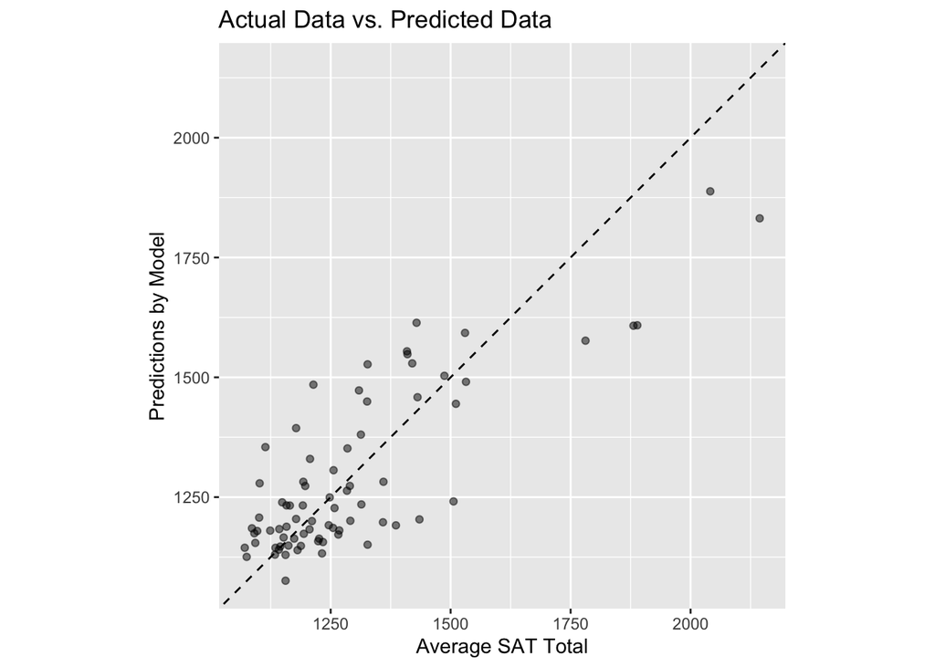

#### Executive Summary

At the end of this modeling process, it is clear that while the performance of the linear regression model is satisfactory, there might be other models that could predict this dataset with increased accuracy. I think a crucial part to increasing the accuracy of this and other models, is obtaining more data. This dataset only ended up including 375 observations (schools). After splitting the data into training and test sets, those sets of data are event smaller. In general, the more data the better. This dataset included all NYC Public High schools with sufficient data. By including more data from more schools outside NYC, in other cities across the country, the modeling would be increasingly accurate.